# HW14: TVs are Runing Our Nation

# Introduction: Nonfatal Injuries from Falling TVs

The goal of the U.S. Consumer Product Safety Commission (CPSC) is to prevent injuries and deaths associated with consumer products. They set regulations that companies must follow when creating or modifying products. The Commission also reviews the safety of existing products. Some of the obvious candidates for review include products that contain chemicals and/or explosives, such as fireworks, paint strippers, and flame retardants. The Commission also collects and analyzes data about less-obvious hazards in order to inform both policy makers and typical consumers. One such less obvious consumer hazard is TV sets that fall on people and cause injury. According to a 2017 report, the majority of incidents (83.5%, 237/284) involved children climbing onto furniture and tipping over the TV.

To better understand and address the dangers of falling TVs, a new survey from the CPSC has collected additional information about TV-falling incidents. The CPSC surveyed 1,000 people who received hospital care for a TV-related injury. They report the following information for each person in this sample population:  
- gender  
- age  
- the channel the patient was watching when it fell (wrestling, comedy, drama, music)  
- height of the TV when it fell  
- weight of the TV  
- the length of stay in the hospital

This report provides a summary of 1) the demographics of the patients and 2) the attributes of the TVs that fell on the patients, and 3) a model to describe which of the factors in the survery influence the severity of the injury. The severity of injury is approximated by the length of stay in the hospital.

# Summary of Patient and TV Attributes

**Age:** Contrary to the 2017 report which found that the majority (83.5%) of TV-falling patients surveyed were under the age of 5, the patients in this survery range widely in age and are not dominated by a single age group. Children do not comprise a majority of TV victims in this sample, as 203/1000 patients (20.3%) were under the age of 10, and 100/1000 (10%) under the age of 5. As shown below, the distribution of age seems uniform from age 0-35, with a reduction in injuries occuring after age 40 and a more dramatic reduction after age 50. Only 88/1000 (8.8%) patients are over 50 years old.

**Length of Stay:** The response variable is close to normally distributed. The mean length of stay is `10.2` days.

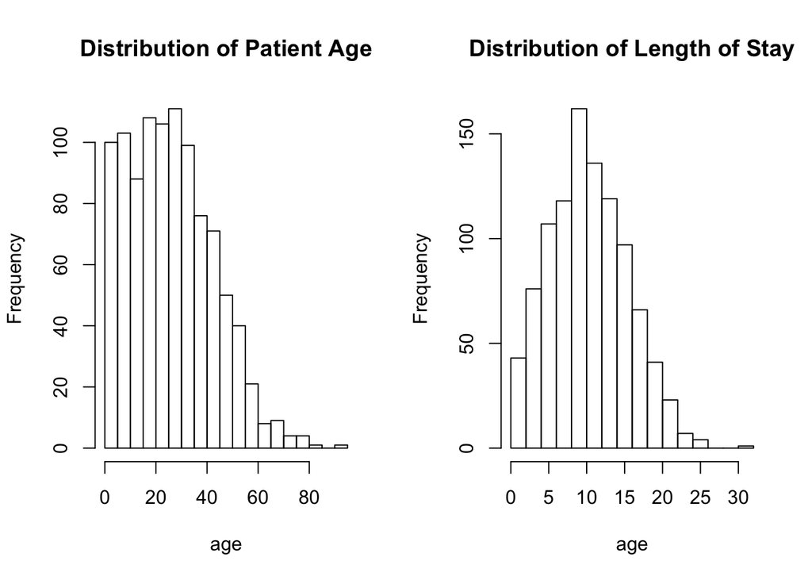

**Gender:** The gender of patients in this survey is split quite evenly between the two genders that were reported: 501/1000 male (50.1% ) and 499/1000 female (49.9%).

**Channel:** The frequency of channels watched while a TV injury occurred is also relatively evenly distributed: 229 injuries associated with channel 1 (wrestling), 237 with channel 2 (comedy), 268 with channel 3 (drama), 266 with channel 4 (music).

The two plots below illustrate how age, gender, and channel are associated with the patients’ length of stay in the hospital. The length of stay seems to decrease with age. Accordingly, the correlation coefficient of these factors is `-0.25`, suggesting a moderate negative correlation between age and length of stay. By mapping gender onto this correlation plot, we can see that the two reported genders are distributed relatively evenly throughout the values of “length of stay”, which suggests that the length of stay does not differ by gender. This observation is supported by the results of a t-test, since the null hypothesis that the true difference in the mean length of stay for males and females is equal to 0 cannot be rejected (t = 1.01, df = 997, p = 0.31).  
Furthermore, there is no obvious relationship between channel and length of stay, since the different colors which represent different channels are not separated on the y-axis which plots the length of stay. It is also interesting to note that channel is also not obviously associated with age, shown on the x-axis.

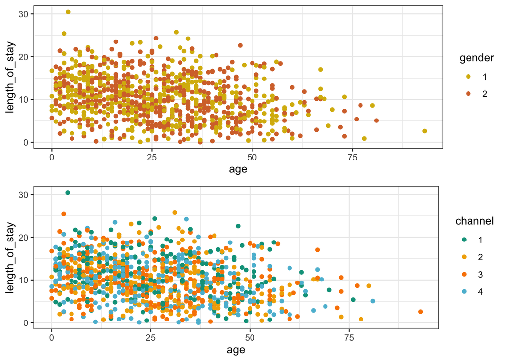

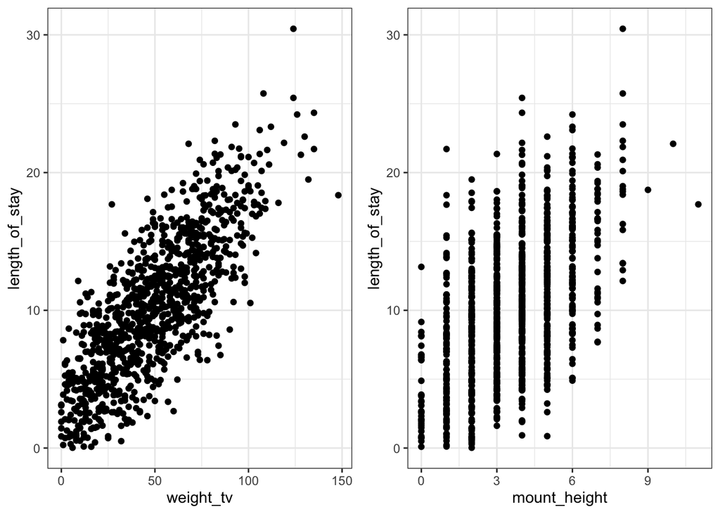

This exploratory data analysis has shown us the makeup of the data in terms of the percentage of each gender represented, the age distribution, and the correlations of all 5 factors with the length of stay. To more formally ascertain how these various factors influence the length of stay, I next fit a model to the data, estimated coefficients for each factor, and determined how well the model describes the data.

# Fitting a Model

Because the distribution of the length of stay (shown above) resembles a normal distribution, a linear model seems appropriate because it assumes the residuals or “noise” is normally distributed. I first fit the model using all the factors recorded in the survey. I included only additive effects because I thought these effects would be more important for the CDC to focus its resources. Furthermore, I did not notice any interaction effects in the data visualization above.

`length_of_stay ~ mount_height + mount_weight + age + gender + channel`

**Results:** Of the 5 factors included in the model, mount height (estimate = 1.44 +- 0.013, p = <2e-16 ), mount weight (est. = 0.15 +- 0.001, p = <2e-16 ), and age (-0.02 +- 0.002, p = <2e-16 ) significantly contribute to the model.

# Assessing the fit of the model

To make sure dropping the other 2 factors, channel and gender, was the right decision and did not affect the fit of the model, I used an ANOVA to compare the fit of the two models. `length_of_stay ~ mount_height + mount_weight + age + gender + channel`  
vs.  
`length_of_stay ~ mount_height + TV_weight + age`

| Res.Df | RSS | Df | Sum of Sq | F | Pr(>F) |
| --- | --- | --- | --- | --- | --- |
| 992 | 615.968 |  |  |  |  |
| 996 | 618.391 | -4 | -2.423 | 0.976 | 0.42 |

From the results of the ANOVA table, we see that the residual sum of squares (RSS) are quite similar between the full and reduced model. Indeed, the difference betweent the RSS is not statistically significant, since the p-value for the F-statistic (pr(>F) is `0.42`.

# Results and Recommendations for the CDC

This report suggests that older patients are less affected by falling TVs. TVs mounted at taller heights are more dangerous, and heavier TVs are more dangerous. My recommendations for CDC would be to consider investing in better TV mounting equipment. Especially if young people between the ages of 0-20 years old live in a household, consider buying less heavy TVs. I think the data suggest that the most effective way to prevent injury or reduce injury severity is to not mount the TVs at tall heights.

# Sources

- Consumer Product Safety Commission: CPSC staff Technical Report - In-Depth Analysis of Nonfatal Injuries from TVs Falling off Furniture  
  https://www.cpsc.gov/s3fs-public/NonFatalTVInjuriesreportOctober2016March17_0.pdf